# ANOVA Assumptions Kruskal-Wallis

## Introduction: Topics

- We have discussed one-way ANOVA.
  - This allows us to compare a continuous variable across multiple groups.
  - One-way ANOVA with two groups is a fancy two-sample *t*-test.
- Today, we will continue on with one-way ANOVA:
  - ANOVA assumptions
  - Nonparametric alternative: Kruskal-Wallis
    - posthoc testing

## Introduction: ANOVA Assumptions

- We previously discussed testing three or more means using ANOVA.
- We also discussed that ANOVA is an extension of the two-sample *t*-test.
- Recall that the *t*-test has two assumptions:
  - Equal variance between groups.
  - Normal distribution.
- We will now extend our knowledge of checking assumptions.

## ANOVA Assumptions: Definition

- We can represent ANOVA with the following model:

$$y_{ij} = \mu + \tau_i + \varepsilon_{ij}$$

- where:
  - $y_{ij}$ is the $j^{\text{th}}$ observation in the $i^{\text{th}}$ group,
  - $\mu$ is the overall (grand) mean,
  - $\tau_i$ is the treatment effect for group $i$, and
  - $\varepsilon_{ij}$ is the error term for the $j^{\text{th}}$ observation in the $i^{\text{th}}$ group.

## ANOVA Assumptions: Definition

- We assume that the error term follows a normal distribution with mean 0 and a constant variance, $\sigma^2$. i.e.,
  $$\varepsilon_{ij} \overset{\text{iid}}{\sim} N(0, \sigma^2)$$
- Very important note: **the assumption is on the error term** and NOT on the outcome!
- We will use the residual (the difference between the observed value and the predicted value) to assess assumptions:
  $$e_{ij} = y_{ij} - \hat{y}_{ij}$$

## ANOVA Assumptions: Graphical Assessment

- **Normality**: quantile-quantile plot
  - Should have points close to the 45$^\circ$ line
  - We will focus on the “center” portion of the plot
- **Variance**: scatterplot of the residuals against the predicted values
  - Should be “equal spread” between the groups
  - No “pattern”

## ANOVA Assumptions: Graphical Assessment (R)

- Like with *t*-tests, we will assess these assumptions graphically.
- We will use the `ANOVA_assumptions()` function from `library(ssstats)` to request the graphs necessary to asssess our assumptions.

```r
dataset_name %>% ANOVA_assumptions(continuous = continuous_variable,
                                   grouping = grouping_variable)
```

## ANOVA Assumptions: Graphical Assessment

- To investigate this, data is collected (*magical_studies*) on a random sample of ponies from each pony type (*pony_type*). Twilight Sparkle wants to know if there is difference in magical coordination scores (*coordination_score*) among the four pony types.
- Let’s now check the ANOVA assumptions. How should we change the following code?

```r
dataset_name %>% ANOVA_assumptions(continuous = continuous_variable,
                                   grouping = grouping_variable)
```

## ANOVA Assumptions: Graphical Assessment

- To investigate this, data is collected (*magical_studies*) on a random sample of ponies from each pony type (*pony_type*). Twilight Sparkle wants to know if there is difference in magical coordination scores (*coordination_score*) among the four pony types.
- Let’s now check the ANOVA assumptions. Our updated code:

```r
magical_studies %>% ANOVA_assumptions(continuous = coordination_score,
                                      grouping = pony_type)
```

## ANOVA Assumptions: Graphical Assessment

- Running the code,

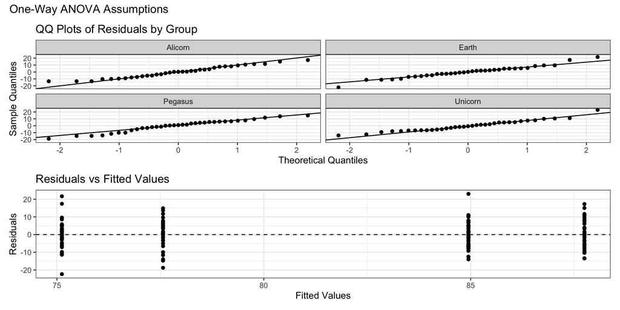

```r
magical_studies %>% ANOVA_assumptions(continuous = coordination_score,
                                      grouping = pony_type)
```

## ANOVA Assumptions: Test for Variance (R)

- We can formally check the variance assumption with the Brown-Forsythe-Levene test (yes, from Module 1!).
- **Hypotheses**
  - $H_0: \ \sigma^2_1 = \sigma^2_2 = ... = \sigma^2_k$
  - $H_1:$ at least one $\sigma^2_i$ is different.
- Recall the `variances_HT()` function from `library(ssstats)`.

```r
dataset_name %>% variances_HT(continuous = continuous_variable,
                              grouping = grouping_variable)
```

## ANOVA Assumptions: Test for Variance

- To investigate this, data is collected (*magical_studies*) on a random sample of ponies from each pony type (*pony_type*). Twilight Sparkle wants to know if there is difference in magical coordination scores (*coordination_score*) among the four pony types.
- Let’s now check the ANOVA assumptions. How should we change the following code?

```r
dataset_name %>% variances_HT(continuous = continuous_variable,
                              grouping = grouping_variable)
```

## ANOVA Assumptions: Test for Variance

- To investigate this, data is collected (*magical_studies*) on a random sample of ponies from each pony type (*pony_type*). Twilight Sparkle wants to know if there is difference in magical coordination scores (*coordination_score*) among the four pony types.
- Let’s now check the ANOVA assumptions. Our updated code:

```r
magical_studies %>% variances_HT(continuous = coordination_score,
                                 grouping = pony_type)
```

## ANOVA Assumptions: Test for Variance

- Running the code,

```r
magical_studies %>% variances_HT(continuous = coordination_score,
                                 grouping = pony_type)
```

```
Brown-Forsythe-Levene test for equality of variances:
Null: σ²_Unicorn = σ²_Pegasus = σ²_Earth = σ²_Alicorn
Alternative: At least one variance is different
Test statistic: F(3,136) = 0.185
p-value: p = 0.906
Conclusion: Fail to reject the null hypothesis (p = 0.9063 ≥ α = 0.05)
```

## Introduction: Kruskal-Wallis

- We just discussed the ANOVA assumptions.

$$\varepsilon_{ij} \overset{\text{iid}}{\sim} N(0, \sigma^2)$$

- We also discussed how to assess the assumptions:
  - Graphically using the `ANOVA_assumptions()` function.
  - Confirming the variance assumption using the BFL (`variances_HT()`).
- If we break either assumption, we will turn to the nonparametric alternative, the Kruskal-Wallis.

## Hypothesis Testing: Kruskal-Wallis

- If we break ANOVA assumptions, we should implement the nonparametric version, the Kruskal-Wallis.
  - The Kruskal-Wallis is an extension of the Wilcoxon rank sum (as ANOVA is an extension of the two-sample *t*-test).
- The Kruskal-Wallis test determines if $k$ independent samples come from populations with the same distribution.
- **Hypotheses**
  - $H_0: M_1 = ... = M_k$
  - $H_1:$ at least one $M_i$ is different

## Hypothesis Testing: Kruskal-Wallis

- **Test Statistic**

$$\chi^2_0 = \frac{12}{n(n+1)} \sum_{i=1}^k \frac{R_i^2}{n_i} - 3(n+1) \sim \chi^2_{\text{df}}$$

- where
  - $R_i$ is the sum of the ranks for group $i$,
  - $n_i$ is the sample size for group $i$,
  - $n = \sum_{i=1}^k n_i$ = total sample size,
  - $k$ is the number of groups, and
  - $\text{df} = k-1$

## Hypothesis Testing: Kruskal-Wallis (R)

- We will use the `kruskal_HT()` function from `library(ssstats)` to perform the Kruskal-Wallis test.

```r
dataset_name %>% kruskal_HT(continuous = continuous_variable,
                            grouping = grouping_variable,
                            alpha = specified_alpha)
```

## Hypothesis Testing: Kruskal-Wallis

- Twilight Sparkle is now conducting an experiment to evaluate the magical pulse activity of a new alchemical potion. She hypothesizes that the potion may affect ponies depending type. To investigate, she carefully measures the number of magical pulses emitted per minute after administering the potion to different ponies.
- For each pony, she collects data (*magical_pulse*) and records the number of magical pulses observed during a one-minute interval (*pulse*). Twilight suspects that the average number of pulses might differ slightly between groups (*pony_type*), but she is unsure whether any differences are meaningful.
- Let’s explore the data first. Due to number of groups, we know either ANOVA or Kruskal-Wallis is required.

## Hypothesis Testing: Kruskal-Wallis

- She collects data (*magical_pulse*) for each pony and records the number of magical pulses observed during a one-minute interval (*pulse*). Twilight suspects that the average number of pulses might differ slightly between groups (*pony_type*), but she is unsure whether any differences are meaningful.

```r
magical_pulse %>%
  group_by(pony_type) %>%
  mean_median(pulse)
```

```
# A tibble: 3 × 4
  pony_type variable mean_sd   median_iqr
  <chr>     <chr>    <chr>     <chr>
1 Earth     pulse    5.0 (2.3) 4.5 (3.0)
2 Pegasus   pulse    6.1 (2.2) 5.5 (2.0)
3 Unicorn   pulse    4.5 (2.2) 4.0 (3.0)
```

## Hypothesis Testing: Kruskal-Wallis

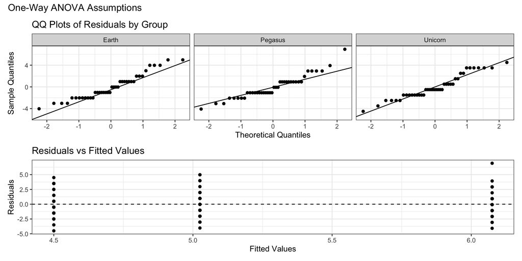

```r
magical_pulse %>% ANOVA_assumptions(continuous = pulse,
                                    grouping = pony_type)
```

## Hypothesis Testing: Kruskal-Wallis

- For each pony, she collects data (*magical_pulse*) and records the number of magical pulses observed during a one-minute interval (*pulse*). Twilight suspects that the average number of pulses might differ slightly between groups (*pony_type*), but she is unsure whether any differences are meaningful. Let’s now perform the appropriate hypothesis test. Test at the $\alpha=0.05$ level.
- How should we change the following code?

```r
dataset_name %>% kruskal_HT(continuous = continuous_variable,
                            grouping = grouping_variable,
                            alpha = specified_alpha)
```

## Hypothesis Testing: Kruskal-Wallis

- For each pony, she collects data (*magical_pulse*) and records the number of magical pulses observed during a one-minute interval (*pulse*). Twilight suspects that the average number of pulses might differ slightly between groups (*pony_type*), but she is unsure whether any differences are meaningful. Let’s now perform the appropriate hypothesis test. Test at the $\alpha=0.05$ level.
- Our updated code,

```r
magical_pulse %>% kruskal_HT(continuous = pulse,
                             grouping = pony_type)
```

## Hypothesis Testing: Kruskal-Wallis

- Running the code,

```r
magical_pulse %>% kruskal_HT(continuous = pulse,
                             grouping = pony_type)
```

```
Kruskal–Wallis Rank-Sum Test

H₀: M_Earth = M_Pegasus = M_Unicorn
H₁: At least one group is different

Test Statistic: X(2) = 10.616,
p = 0.005
Conclusion: Reject the null hypothesis (p = 0.005 < α = 0.05)
```

## Hypothesis Testing: Kruskal-Wallis

- **Hypotheses**
  - $H_0: \ M_{\text{earth}} = M_{\text{pegasus}} = M_{\text{unicorn}}$
  - $H_1:$ at least one $M_i$ is different
- **Test Statistic and *p*-Value**
  - $\chi_0^2 = 10.616$; $p = 0.005$
- **Rejection Region**
  - Reject $H_0$ if $p < \alpha$; $\alpha=0.05$.
- **Conclusion/Interpretation**
  - Reject $H_0$ ($p \text{ vs } \alpha \to p = 0.005 < 0.05$). There is sufficient evidence to suggest that there is a difference in pulse between the pony types.

## Posthoc Testing: Dunn’s Test

- We can also perform posthoc testing in the Kruskal-Wallis setting using Dunn’s test.
  - Rather than compare pairwise means, it compares pairwise average ranks.
- **Hypotheses:**
  - $H_0: \ M_{i} = M_{j}$
  - $H_1: \ M_{i} \ne M_{j}$
- **Test Statistic:**

$$z_0 = \frac{|\bar{R}_i - \bar{R}_j|}{\sqrt{ \frac{n(n+1)}{12} \left( \frac{1}{n_i} + \frac{1}{n_j} \right) }}$$

## Posthoc Testing: Dunn’s Test

- !! WAIT !! What about adjusting $\alpha$?
- The function we will be using allows us to turn on/off the adjustment for multiple comparison.
- To adjust the $p$-value directly,

$$p_{\text{B}} = \min(p \times m,\ 1)$$

- The adjustment can also be made directly to $\alpha$ (and not $p$),

$$\alpha_{\text{B}} = \frac{\alpha}{m}$$

## Posthoc Testing: Dunn’s Test (R)

- We will use the `posthoc_dunn()` function from `library(ssstats)` to perform Dunn’s posthoc test.
- When we want to adjust $\alpha$ (Bonferroni):

```r
dataset_name %>% posthoc_dunn(continuous = continuous_variable,
                              grouping = grouping_variable,
                              adjust = TRUE)
```

- When we do not want to adjust $\alpha$:

```r
dataset_name %>% posthoc_dunn(continuous = continuous_variable,
                              grouping = grouping_variable,
                              adjust = FALSE)
```

## Posthoc Testing: Dunn’s Test

- For each pony, she collects data (*magical_pulse*) and records the number of magical pulses observed during a one-minute interval (*pulse*). Twilight suspects that the average number of pulses might differ slightly between groups (*pony_type*), but she is unsure whether any differences are meaningful. Test at the $\alpha=0.05$ level.
- Let’s now examine posthoc testing. Suppose we are not interested in adjusting for multiple comparisons (this is an exploratory study). How should we change this code?

```r
dataset_name %>% posthoc_dunn(continuous = continuous_variable,
                              grouping = grouping_variable,
                              adjust = TRUE OR FALSE)
```

## Posthoc Testing: Dunn’s Test

- For each pony, she collects data (*magical_pulse*) and records the number of magical pulses observed during a one-minute interval (*pulse*). Twilight suspects that the average number of pulses might differ slightly between groups (*pony_type*), but she is unsure whether any differences are meaningful. Test at the $\alpha=0.05$ level.
- Let’s now examine posthoc testing. Suppose we are not interested in adjusting for multiple comparisons (this is an exploratory study). Our updated code,

```r
magical_pulse %>% posthoc_dunn(continuous = pulse,
                               grouping = pony_type,
                               adjust = FALSE)
```

## Posthoc Testing: Dunn’s Test

- Running the code,

```r
magical_pulse %>% posthoc_dunn(continuous = pulse,
                               grouping = pony_type,
                               adjust = FALSE)
```

```
         Comparison          Z     p
1   Earth - Pegasus -2.2183479 0.027
2   Earth - Unicorn  0.9574435 0.338
3 Pegasus - Unicorn  3.1757915 0.001
```

## Posthoc Testing: Dunn’s Test

- Restating results,
  - $M_{\text{earth}} \ne M_{\text{pegasus}}$ ($p = 0.027$)
  - $M_{\text{earth}} = M_{\text{unicorn}}$ ($p = 0.338$)
  - $M_{\text{pegasus}} \ne M_{\text{unicorn}}$ ($p = 0.001$)

## Posthoc Testing: Dunn’s Test

- For each pony, she collects data (*magical_pulse*) and records the number of magical pulses observed during a one-minute interval (*pulse*). Twilight suspects that the average number of pulses might differ slightly between groups (*pony_type*), but she is unsure whether any differences are meaningful. Test at the $\alpha=0.05$ level.
- Let’s now examine posthoc testing. Suppose we do want toadjust for multiple comparisons (this is a confirmatory study). How should we change this code?

```r
dataset_name %>% posthoc_dunn(continuous = continuous_variable,
                              grouping = grouping_variable,
                              adjust = TRUE OR FALSE)
```

## Posthoc Testing: Dunn’s Test

- For each pony, she collects data (*magical_pulse*) and records the number of magical pulses observed during a one-minute interval (*pulse*). Twilight suspects that the average number of pulses might differ slightly between groups (*pony_type*), but she is unsure whether any differences are meaningful. Test at the $\alpha=0.05$ level.
- Let’s now examine posthoc testing. Suppose we do want toadjust for multiple comparisons (this is a confirmatory study). How should we change this code?

```r
magical_pulse %>% posthoc_dunn(continuous = pulse,
                               grouping = pony_type,
                               adjust = TRUE)
```

## Posthoc Testing: Dunn’s Test

- Running the code,

```r
magical_pulse %>% posthoc_dunn(continuous = pulse,
                               grouping = pony_type,
                               adjust = TRUE)
```

```
         Comparison          Z     p
1   Earth - Pegasus -2.2183479 0.080
2   Earth - Unicorn  0.9574435 1.000
3 Pegasus - Unicorn  3.1757915 0.004
```

## Posthoc Testing: Dunn’s Test

- Comparing the two side by side,

| Pairwise Comparison | Unadjusted $p$ | Adjusted $p$ |
| --- | --- | --- |
| Earth vs. Pegasus | 0.027 | 0.080 |
| Earth vs. Unicorn | 0.338 | 1.000 |
| Pegasus vs. Unicorn | 0.001 | 0.004 |

## Wrap Up

- Today we have covered one-way ANOVA.
  - One-way ANOVA table
  - Test for equality among $k$ means
  - ANOVA assumptions
  - Nonparametric alternative (Kruskal-Wallis)
  - Posthoc testing
    - Tukey’s (ANOVA, ajdusted)
    - Fisher’s (ANOVA, unadjusted)
    - Dunn’s (Kruskal-Wallis, adjusted or unadjusted)

## Wrap Up

- Next class:
  - Lab: One-way ANOVA and Kruskal-Wallis
  - Quiz: One-way ANOVA and Kruskal-Wallis
- Next week:
  - Monday: No class (Columbus Day)
  - Tuesday: Catch up period, 4/305, 9:30-10:45
  - Meeting 2: Two-way ANOVA lecture